# Homework 2

Dylan Maddux

2023-09-13

# Question 1

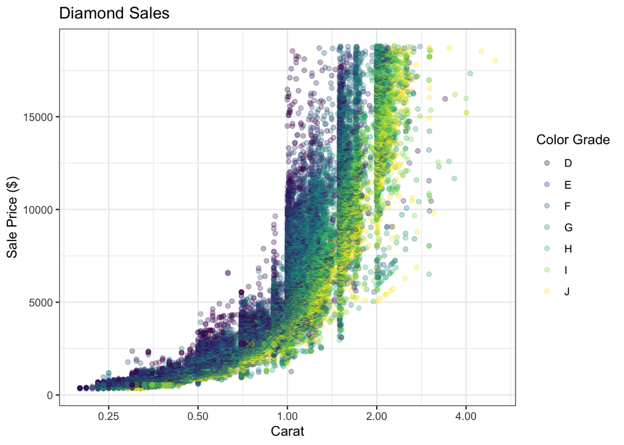

```r
library(ggplot2)
data("diamonds")
ggplot(diamonds, aes(carat, price, color = color)) +
  geom_point(alpha = 0.3) +
  labs(x = "Carat", y = "Sale Price ($)", title = "Diamond Sales", color = "Color Grade") +
  scale_x_continuous(trans = "log2", breaks = c(0.25, 0.5, 1, 2, 4), labels = c("0.25", "0.50", "1.00", "2.00", "4.00")) +
  theme_bw()
```

# Part 1

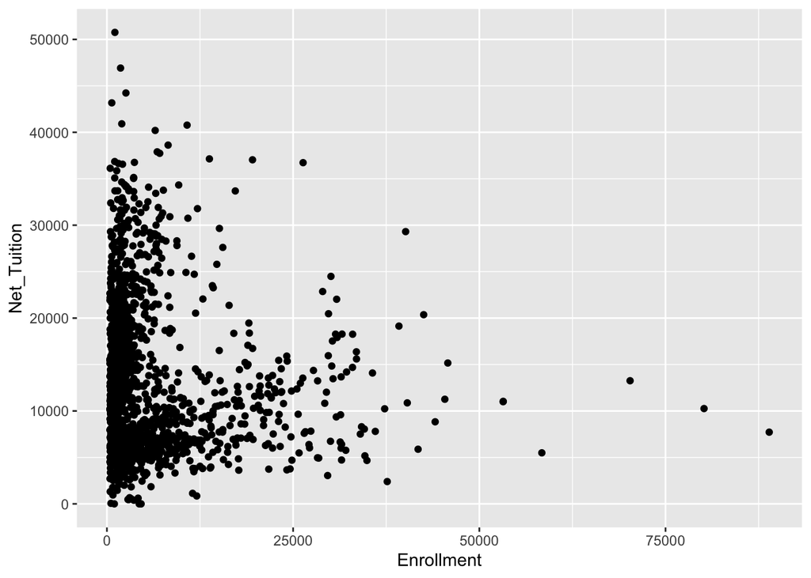

```r
colleges <- read.csv("https://remiller1450.github.io/data/Colleges2019.csv")
ggplot(colleges, aes(Enrollment, Net_Tuition)) +
geom_point()
```

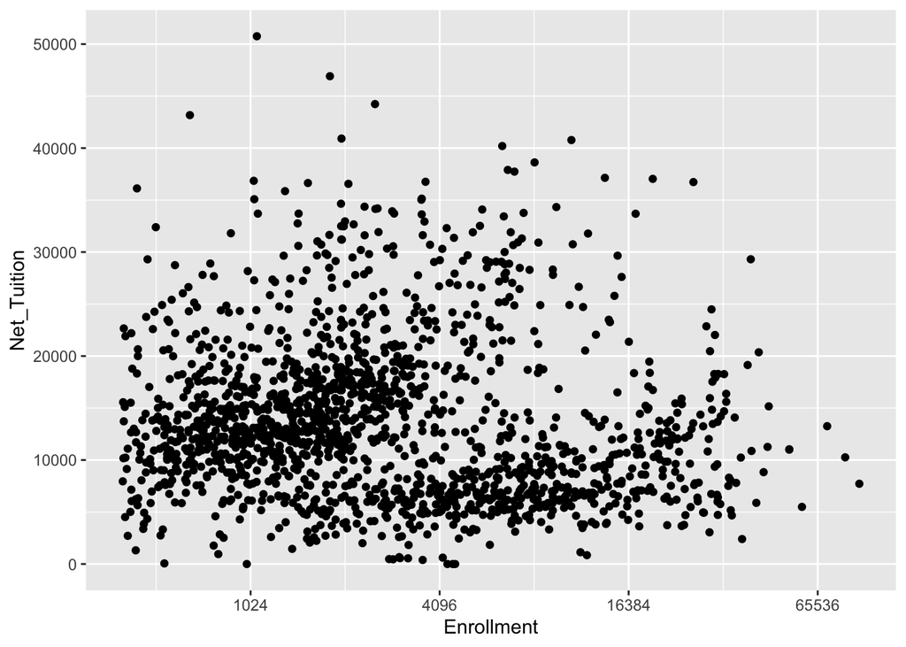

```r
ggplot(colleges, aes(Enrollment, Net_Tuition)) +
geom_point() +
  scale_x_continuous(trans = "log2")
```

The enrollment numbers are massively skewed towards the lower numbers in the first plot, with a few outliers in the higher enrollment numbers. In the transformed plot, the enrollment numbers increase logarithmically, with the x-axis breaks being multiplied by 4 each time, therefore distributing the plot points more evenly across the graph since more of the points are at the lower end of the enrollment count.

# Part 2

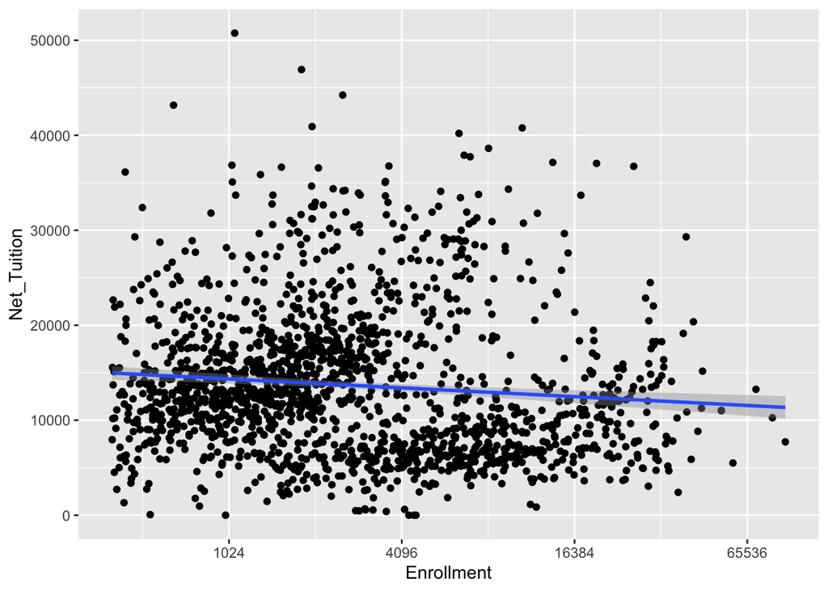

```r
ggplot(colleges, aes(Enrollment, Net_Tuition)) +
geom_point()+
  geom_smooth(method = "lm") +
  scale_x_continuous(trans = "log2")
```

Tuition and enrollment appear to be slightly negatively correlated, with the tuition decreasing slightly as the enrollment increases.

# Part 3

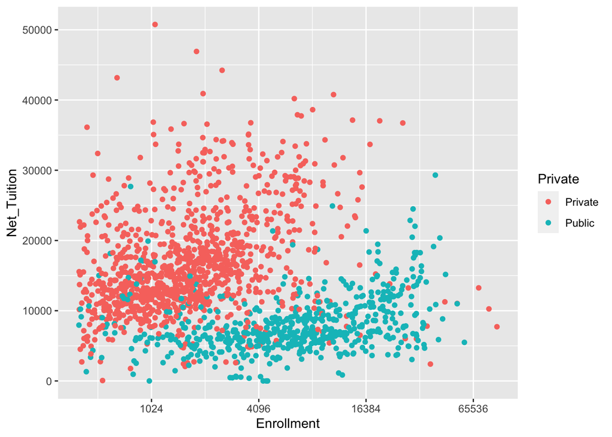

```r
ggplot(colleges, aes(Enrollment, Net_Tuition, color = Private)) +
geom_point() +
  scale_x_continuous(trans = "log2")
```

The private university group tends to a haver higher tuition and lower enrollment count than the public university group.

# Part 4

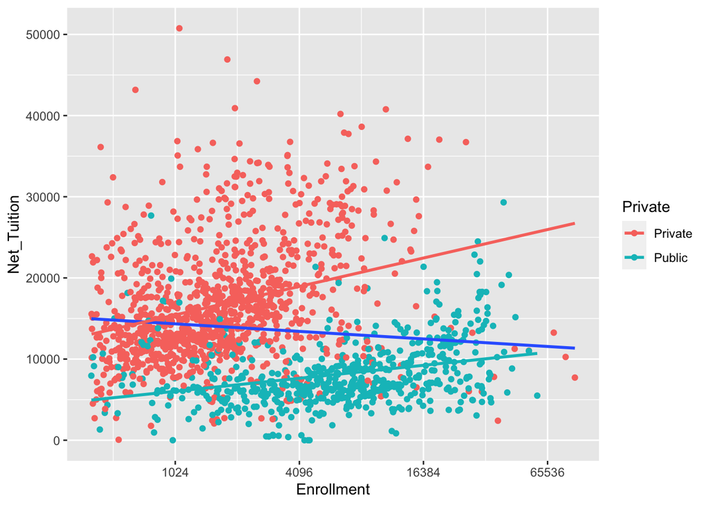

```r
ggplot(colleges, aes(Enrollment, Net_Tuition)) +
  geom_point(aes(color = Private)) +
  geom_smooth(method = "lm", se = FALSE) +
geom_smooth(method = "lm", se = FALSE, aes(color = Private)) +
  scale_x_continuous(trans = "log2")
```

Tuition and enrollment are positively correlated for both private and public colleges since the line of best is increasing, whereas they are negatively correlated for all colleges since the line of best fit is decreasing.

# Question 3

```r
hair <- as.data.frame(HairEyeColor)
```

# Part 1

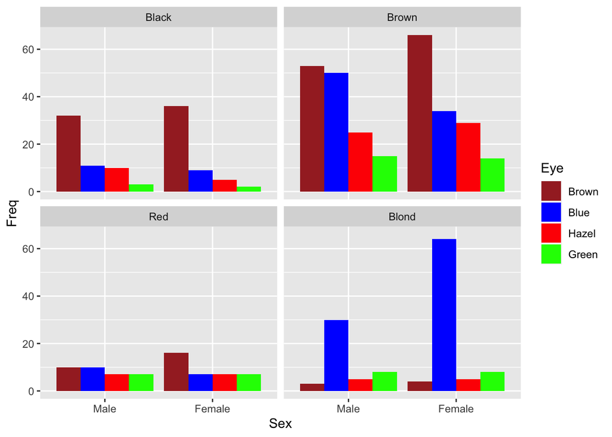

```r
ggplot(hair, aes(Sex, Freq, fill = Eye)) +
  geom_bar(stat = "identity", position = "dodge") +
    facet_wrap(~Hair) +
    scale_fill_manual(values=c('brown', 'blue', "red", "green"))
```

1. The distribution of eye color appears to be different between sexes.
2. More blonde women have blue eyes, more brown-haired women have brown eyes, and more brown-haired men have blue eyes. Blond people have a strong association with blue eyes. Red-haired people have little differentiation between eye colors. Both men and women with black hair and women with brown hair tend to have brown eyes, while men with brown hair are likely to have either brown or blue eyes.

# Part 2

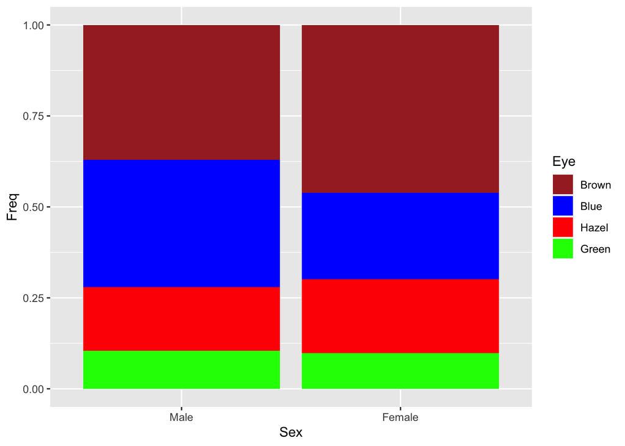

```r
sub_brown <- subset(hair, Hair == "Brown")
ggplot(sub_brown, aes(Sex, Freq, fill = Eye)) +
  geom_bar(stat="identity", position="fill") +
      scale_fill_manual(values=c('brown', 'blue', "red", "green"))
```

Based on this plot, women seem to have a greater composition of brown eyes, while men tend to have a greater composition of blue eyes.